# Columbidae Urban Community Nestedness

```r
col_loc = read_csv('./bigquery_export__columbidae_jetz_urban_locations.csv')
head(col_loc)
```

| city_id | city_name | jetz_scientific_name | present_in_city | season_code | season | origin_code | origin |
| --- | --- | --- | --- | --- | --- | --- | --- |
| 1 | Honolulu | Stigmatopelia_chinensis | FALSE | 1 | Resident | 3 | Introduced |
| 514 | Cali | Columbina_passerina | FALSE | 1 | Resident | 1 | Native |
| 514 | Cali | Columbina_talpacoti | TRUE | 1 | Resident | 1 | Native |
| 514 | Cali | Geotrygon_montana | FALSE | 1 | Resident | 1 | Native |
| 514 | Cali | Claravis_mondetoura | FALSE | 1 | Resident | 1 | Native |
| 514 | Cali | Leptotila_plumbeiceps | FALSE | 1 | Resident | 1 | Native |

[output not shown]

[output cut: 500 more lines]

> Function nestedtemp finds the matrix temperature which is defined as the sum of “surprises” in arranged matrix. In arranged unsurprising matrix all species within proportion given by matrix fill are in the upper left corner of the matrix, and the surprise of the absence or presences is the diagonal distance from the fill line (Atmar & Patterson 1993). Function tries to pack species and sites to a low temperature (Rodríguez-Gironés & Santamaria 2006), but this is an iterative procedure, and the temperatures usually vary among runs. Function nestedtemp also has a plot method which can display either incidences or temperatures of the surprises. Matrix temperature was rather vaguely described (Atmar & Patterson 1993), but Rodríguez-Gironés & Santamaria (2006) are more explicit and their description is used here. However, the results probably differ from other implementations, and users should be cautious in interpreting the results. The details of calculations are explained in the vignette Design decisions and implementation that you can read using functions browseVignettes. Function nestedness in the bipartite package is a direct port of the BINMATNEST programme of Rodríguez-Gironés & Santamaria (2006).

```r
temp <- nestedtemp(species_city_presence)
temp
```

```
nestedness temperature: 0.08148348
with matrix fill 0.01345588
```

[figure not shown]

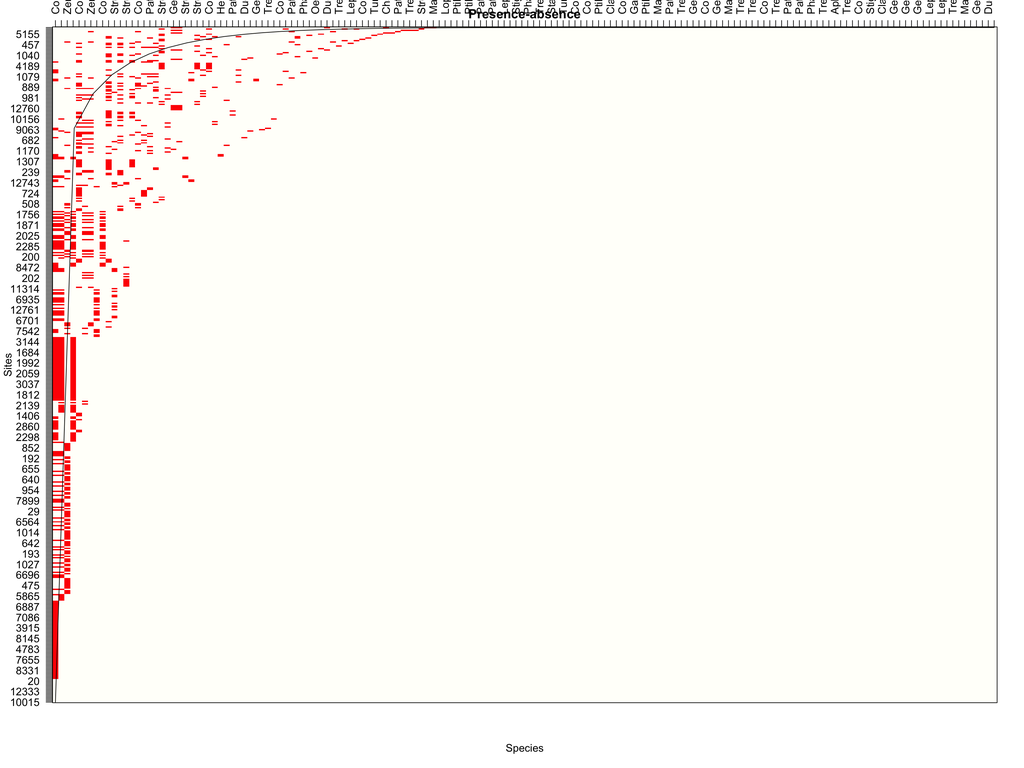

```r
jpeg("./figures/community_nestedness.jpg", width = 778, height=512)
plot(temp, kind="incidence",xlab = "Species", ylab="Sites",main="Presence-absence")
dev.off()
```

> Function nestedchecker gives the number of checkerboard units, or 2x2 submatrices where both species occur once but on different sites (Stone & Roberts 1990).

```r
nestedchecker(species_city_presence)
```

[output not shown]

> The nestedness functions evaluate alternative indices of nestedness. The functions are intended to be used together with Null model communities and used as an argument in oecosimu to analyse the non-randomness of results.

```r
oecosimu(species_city_presence, nestedtemp, "quasiswap")
```

[output not shown]

```r
oecosimu(species_city_presence, nestedchecker, "quasiswap")
```

[output not shown]